# Developing Data Products Course Project

2023-09-25

## Introduction

This presentation is a part of the Course Project of Developing Data Products. This project consists of the two parts: to develop a Shiny application and publish it on Rstudio’s servers and to create a reproducible pitch presentation about the application. The documentation on this project is as follows:

- The project’s [GitHub repository](https://github.com/randonmess/Developing-Data-Products-Course-Project)
- The [Shiny Application](https://randomess.shinyapps.io/myApp/)

## A Demonstration on Central Limit Theorem

The purpose of the Shiny App is to demonstrate the Central Limit Theorem by plotting the histogram of the mean of five dice rolls, observed for a number of times as indicated by the user of the app. For more reading on the Central Limit Theorem, click [here.](https://www.statology.org/central-limit-theorem/)

## Sample R code

First, select the number of observations, `obvs`. This would be done through user input on the app. It will be set to 1000.

```r
obvs <- 1000
```

Then, 1000 sets of 5 dice rolls are generated, and their means calculated.

```r
set.seed(2023)
rolls <- replicate(obvs, sample(1:6, 5, replace = T))
means <- colMeans(rolls)
```

Then a histogram of `means` is plotted.

## Histogram

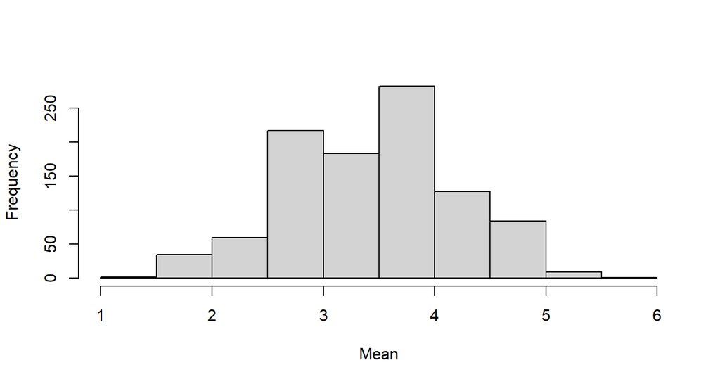

As seen from the plot, the distribution of `means` is roughly normal as according to the Central Limit Theorem.